# **Predicción de la duración de la estadía en el hospital (LOS)**

## **Contexto:**

La gestión hospitalaria es un área vital que ganó mucha atención durante la pandemia de COVID-19. **La distribución ineficiente de recursos como camas y ventiladores podría generar muchas complicaciones**. Sin embargo, esto se puede mitigar **prediciendo la duración de la estadía (LOS) de un paciente antes de ser admitido**. Una vez que esto se determina, el hospital puede planificar un tratamiento, recursos y personal adecuados para reducir la LOS y aumentar las posibilidades de recuperación. Las habitaciones y la cama también se pueden planificar de acuerdo con eso.

**El hospital HealthPlus ha estado incurriendo en muchas pérdidas en ingresos y vidas debido a su sistema de gestión ineficiente.** No han tenido éxito en la asignación justa de equipos, camas y personal del hospital. **Un sistema que pueda estimar la duración de la estancia (LOS) de un paciente puede resolver este problema en gran medida.**

## **Objetivo:**

Como científico de datos, debe ser contratado por HealthPlus para analizar los datos, averiguar **qué factores afectan más a la LOS y crear un modelo de aprendizaje automático que pueda predecir la LOS de un paciente** utilizando los datos disponibles durante la admisión y después de realizar algunas pruebas. Además, **obtenga información y políticas útiles a partir de los datos, que pueden ayudar al hospital a mejorar su infraestructura de atención médica y sus ingresos.**

## **Diccionario de datos:**

Los datos contienen diversa información registrada durante el tiempo de ingreso del paciente. Solo contiene **registros de pacientes que fueron admitidos en el hospital.** El diccionario de datos detallado se proporciona a continuación:

- **patientid**: ID del paciente
- **Age**: Rango de edad del paciente
- **gender**: Sexo del paciente
- **Type of Admission**: Trauma, emergencia o urgencia
- **Severity of Illness**: Extrema, moderada o menor
- **health_conditions**: Cualquier condición de salud previa que haya sufrido el paciente
- **Visitors with Patient**: El número de visitantes que acompañan al paciente
- **Insurance**: ¿Tiene el paciente seguro médico o no?
- **Admission_Deposit**: El depósito pagado por el paciente durante la admisión
- **Stay (in days)**: El número de días que el paciente ha estado en el hospital. Esta es la **variable objetivo**
- **Available Extra Rooms in Hospital**: El número de habitaciones disponibles durante la admisión
- **Departament**: El departamento que tratará al paciente
- **Ward_Facility_Code**: El código de la instalación de la sala en la que se admitirá al paciente
- **doctor_name**: El médico que tratará al paciente
- **staff_available**: El número de personal que no está ocupado en este momento en la sala

## **Enfoque para resolver el problema:**

1. Importe las bibliotecas necesarias.
2. Lea el conjunto de datos y obtenga una descripción general.
3. Análisis exploratorio de datos. a. Univariado b. Bivariado.
4. Preprocesamiento de datos en su caso.
5. Defina la métrica de rendimiento y cree modelos ML
6. Comprobación de suposiciones
7. Compara modelos y determina cuál es el mejor.
8. Observaciones y conocimientos empresariales.

## **Importación de bibliotecas**

```python
import pandas as pd
import numpy as np
import matplotlib.pyplot as plt
import seaborn as sns

import warnings
warnings.filterwarnings("ignore")

# Removes the limit for the number of displayed columns
pd.set_option("display.max_columns", None)

# Sets the limit for the number of displayed rows
pd.set_option("display.max_rows", 200)

# To build models for prediction
from sklearn.model_selection import train_test_split, cross_val_score, KFold
from sklearn.linear_model import LinearRegression, Ridge, Lasso
from sklearn.tree import DecisionTreeRegressor
from sklearn.ensemble import RandomForestRegressor,BaggingRegressor

from sklearn.preprocessing import LabelEncoder

#for tuning the model
from sklearn.model_selection import GridSearchCV

# To check model performance
from sklearn.metrics import make_scorer,mean_squared_error, r2_score, mean_absolute_error
```

```python
#read the healthcare dataset file
data=pd.read_csv("healthcare_data.csv")
```

```python
# copying data to another variable to avoid any changes to original data
same_data = data.copy()
```

## **Resumen de datos**

```python
# View the first 5 rows of the dataset
data.head()
```

|  | Available Extra Rooms in Hospital | Department | Ward_Facility_Code | doctor_name | staff_available | patientid | Age | gender | Type of Admission | Severity of Illness | health_conditions | Visitors with Patient | Insurance | Admission_Deposit | Stay (in days) |
| --- | --- | --- | --- | --- | --- | --- | --- | --- | --- | --- | --- | --- | --- | --- | --- |
| 0 | 4 | gynecology | D | Dr Sophia | 0 | 33070 | 41-50 | Female | Trauma | Extreme | Diabetes | 4 | Yes | 2966.408696 | 8 |
| 1 | 4 | gynecology | B | Dr Sophia | 2 | 34808 | 31-40 | Female | Trauma | Minor | Heart disease | 2 | No | 3554.835677 | 9 |
| 2 | 2 | gynecology | B | Dr Sophia | 8 | 44577 | 21-30 | Female | Trauma | Extreme | Diabetes | 2 | Yes | 5624.733654 | 7 |
| 3 | 4 | gynecology | D | Dr Olivia | 7 | 3695 | 31-40 | Female | Urgent | Moderate | None | 4 | No | 4814.149231 | 8 |
| 4 | 2 | anesthesia | E | Dr Mark | 10 | 108956 | 71-80 | Male | Trauma | Moderate | Diabetes | 2 | No | 5169.269637 | 34 |

```python
# View the last 5 rows of the dataset
data.tail()
```

|  | Available Extra Rooms in Hospital | Department | Ward_Facility_Code | doctor_name | staff_available | patientid | Age | gender | Type of Admission | Severity of Illness | health_conditions | Visitors with Patient | Insurance | Admission_Deposit | Stay (in days) |
| --- | --- | --- | --- | --- | --- | --- | --- | --- | --- | --- | --- | --- | --- | --- | --- |
| 499995 | 4 | gynecology | F | Dr Sarah | 2 | 43001 | 11-20 | Female | Trauma | Minor | High Blood Pressure | 3 | No | 4105.795901 | 10 |
| 499996 | 13 | gynecology | F | Dr Olivia | 8 | 85601 | 31-40 | Female | Emergency | Moderate | Other | 2 | No | 4631.550257 | 11 |
| 499997 | 2 | gynecology | B | Dr Sarah | 3 | 22447 | 11-20 | Female | Emergency | Moderate | High Blood Pressure | 2 | No | 5456.930075 | 8 |
| 499998 | 2 | radiotherapy | A | Dr John | 1 | 29957 | 61-70 | Female | Trauma | Extreme | Diabetes | 2 | No | 4694.127772 | 23 |
| 499999 | 3 | gynecology | F | Dr Sophia | 3 | 45008 | 41-50 | Female | Trauma | Moderate | Heart disease | 4 | Yes | 4713.868519 | 10 |

```python
#Understand the shape of the data
data.shape
```

```
(500000, 15)
```

- El conjunto de datos tiene **5,00,000 filas y 15 columnas**

```python
#Checking the info of the data
data.info()
```

```
<class 'pandas.core.frame.DataFrame'>
RangeIndex: 500000 entries, 0 to 499999
Data columns (total 15 columns):
 #   Column                             Non-Null Count   Dtype
---  ------                             --------------   -----
 0   Available Extra Rooms in Hospital  500000 non-null  int64
 1   Department                         500000 non-null  object
 2   Ward_Facility_Code                 500000 non-null  object
 3   doctor_name                        500000 non-null  object
 4   staff_available                    500000 non-null  int64
 5   patientid                          500000 non-null  int64
 6   Age                                500000 non-null  object
 7   gender                             500000 non-null  object
 8   Type of Admission                  500000 non-null  object
 9   Severity of Illness                500000 non-null  object
 10  health_conditions                  500000 non-null  object
 11  Visitors with Patient              500000 non-null  int64
 12  Insurance                          500000 non-null  object
 13  Admission_Deposit                  500000 non-null  float64
 14  Stay (in days)                     500000 non-null  int64
dtypes: float64(1), int64(5), object(9)
memory usage: 57.2+ MB
```

**Observaciones:**

- Habitaciones Extra Disponibles en Hospital, personal_disponible, IDpaciente, Visitantes con Paciente, Admisión_Depósito y Estancia (en días) son de **tipo de dato numérico** y el resto de las columnas son de **tipo de datos de objeto*.
- El número de valores no nulos es el mismo que el número total de entradas en los datos, es decir,**no hay valores nulos.**
- La columna ID del paciente es un identificador de pacientes en los datos.

```python
# checking for duplicate values in the Data
data.duplicated().sum()
```

```
0
```

**Observaciones:**

- Los datos solo tienen filas únicas. No es necesario eliminar ninguna fila.

```python
#To view patientid and the number of times they have visited the hospital
data['patientid'].value_counts()
```

```
126719    21
125695    21
44572     21
126623    21
125625    19
          ..
37634      1
91436      1
118936     1
52366      1
105506     1
Name: patientid, Length: 126399, dtype: int64
```

**Observaciones:**

- **El número máximo de veces que un mismo paciente ingresa en el hospital es 21 y el mínimo 1.**

```python
#Checking the descriptive statistics of the columns
data.describe().T
```

|  | count | mean | std | min | 25% | 50% | 75% | max |
| --- | --- | --- | --- | --- | --- | --- | --- | --- |
| Available Extra Rooms in Hospital | 500000.0 | 3.638800 | 2.698124 | 0.000000 | 2.000000 | 3.000000 | 4.000000 | 24.00000 |
| staff_available | 500000.0 | 5.020470 | 3.158103 | 0.000000 | 2.000000 | 5.000000 | 8.000000 | 10.00000 |
| patientid | 500000.0 | 63150.519058 | 41689.479956 | -3269.000000 | 25442.000000 | 57864.000000 | 103392.000000 | 134400.00000 |
| Visitors with Patient | 500000.0 | 3.549414 | 2.241054 | 0.000000 | 2.000000 | 3.000000 | 4.000000 | 32.00000 |
| Admission_Deposit | 500000.0 | 4722.315734 | 1047.324220 | 1654.005148 | 4071.714532 | 4627.003792 | 5091.612717 | 10104.72639 |
| Stay (in days) | 500000.0 | 12.381062 | 7.913174 | 3.000000 | 8.000000 | 9.000000 | 11.000000 | 51.00000 |

**Observaciones:**

```python
# List of all important categorical variables
cat_col = ["Department", "Type of Admission", 'Severity of Illness', 'gender', 'Insurance', 'health_conditions', 'doctor_name', "Ward_Facility_Code", "Age"]

# Printing the number of occurrences of each unique value in each categorical column
for column in cat_col:
    print(data[column].value_counts(1))
    print("-" * 50)
```

```
gynecology            0.686956
radiotherapy          0.168630
anesthesia            0.088358
TB & Chest disease    0.045780
surgery               0.010276
Name: Department, dtype: float64
--------------------------------------------------
Trauma       0.621072
Emergency    0.271568
Urgent       0.107360
Name: Type of Admission, dtype: float64
--------------------------------------------------
Moderate    0.560394
Minor       0.263074
Extreme     0.176532
Name: Severity of Illness, dtype: float64
--------------------------------------------------
Female    0.74162
Male      0.20696
Other     0.05142
Name: gender, dtype: float64
--------------------------------------------------
Yes    0.78592
No     0.21408
Name: Insurance, dtype: float64
--------------------------------------------------
None                   0.303776
Other                  0.188822
High Blood Pressure    0.158804
Diabetes               0.147288
Asthama                0.131028
Heart disease          0.070282
Name: health_conditions, dtype: float64
--------------------------------------------------
Dr Sarah     0.199192
Dr Olivia    0.196704
Dr Sophia    0.149506
Dr Nathan    0.141554
Dr Sam       0.111422
Dr John      0.102526
```

[output cut: 10 more lines]

```
C    0.029194
Name: Ward_Facility_Code, dtype: float64
--------------------------------------------------
21-30     0.319586
31-40     0.266746
41-50     0.160812
11-20     0.093072
61-70     0.053112
51-60     0.043436
71-80     0.037406
81-90     0.016362
0-10      0.006736
91-100    0.002732
Name: Age, dtype: float64
--------------------------------------------------
```

**Observaciones:**

- **La mayoría de los pacientes (~82%) ingresan en el hospital con enfermedades moderadas y leves** lo cual es comprensible ya que las enfermedades extremas son menos frecuentes que las moderadas y leves.
- **El departamento de Ginecología recibe la mayor cantidad de pacientes (~68%)** en el hospital, mientras que los pacientes en el departamento de Cirugía son muy inferiores (~1%).
- **Las salas A y C albergan la menor cantidad de pacientes (~12 %).** Estas salas podrían estar reservadas para pacientes con enfermedades extremas y pacientes que necesitan cirugía. Sería interesante ver si los pacientes de estas salas también se quedan por más tiempo.
- **La mayoría de los pacientes pertenecen al grupo de edad de 21 a 50 (~75%) y son mujeres (~75%).** La mayor cantidad de pacientes en el departamento de ginecología del hospital puede justificar esto.
- La mayoría de los pacientes ingresados en el hospital son los casos de trauma (~ 62%).
- **La presión arterial alta y la diabetes son las condiciones de salud más comunes.**

## **Análisis exploratorio de datos (EDA)**

### **Análisis univariado**

```python
# function to plot a boxplot and a histogram along the same scale.


def histogram_boxplot(data, feature, figsize=(12, 7), kde=False, bins=None):
    """
    Boxplot and histogram combined

    data: dataframe
    feature: dataframe column
    figsize: size of figure (default (12,7))
    kde: whether to the show density curve (default False)
    bins: number of bins for histogram (default None)
    """
    f2, (ax_box2, ax_hist2) = plt.subplots(
        nrows=2,  # Number of rows of the subplot grid= 2
        sharex=True,  # x-axis will be shared among all subplots
        gridspec_kw={"height_ratios": (0.25, 0.75)},
        figsize=figsize,
    )  # creating the 2 subplots
    sns.boxplot(
        data=data, x=feature, ax=ax_box2, showmeans=True, color="violet"
    )  # boxplot will be created and a star will indicate the mean value of the column
    sns.histplot(
        data=data, x=feature, kde=kde, ax=ax_hist2, bins=bins, palette="winter"
    ) if bins else sns.histplot(
        data=data, x=feature, kde=kde, ax=ax_hist2
    )  # For histogram
    ax_hist2.axvline(
        data[feature].mean(), color="green", linestyle="--"
    )  # Add mean to the histogram
    ax_hist2.axvline(
        data[feature].median(), color="black", linestyle="-"
    )  # Add median to the histogram
```

#### **Duración de la estancia**

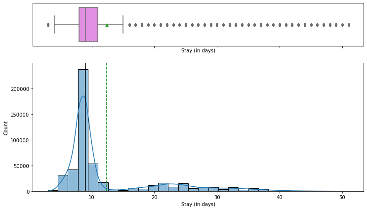

```python
histogram_boxplot(data, "Stay (in days)", kde=True, bins=30)
```

**Observaciones:**

- Hay **menos número de pacientes que permanecen más de 10 días en el hospital y muy pocos que permanecen más de 40 días**. Esto podría deberse a que la mayoría de los pacientes ingresan por una enfermedad moderada o leve.
- El pico de la distribución muestra que la mayoría de los pacientes permanecen entre 8 y 9 días en el hospital.

#### **Depósito de entrada**

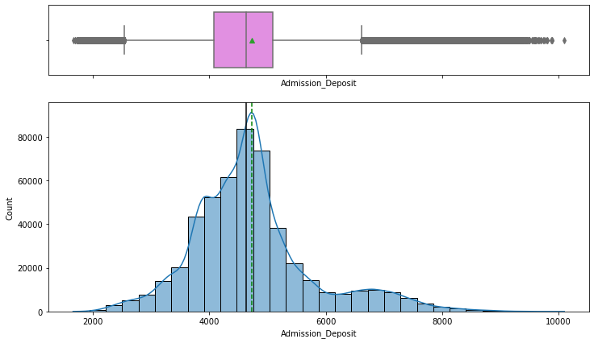

```python
histogram_boxplot(data, "Admission_Deposit", kde=True, bins=30)
```

**Observaciones:**

- La **distribución de las tarifas de admisión es casi normal con valores atípicos en ambos lados**. Hay pocos pacientes que pagan una gran cantidad de tarifas de admisión y pocos pacientes que pagan una cantidad baja de tarifas de admisión.

#### **Visitantes con pacientes**

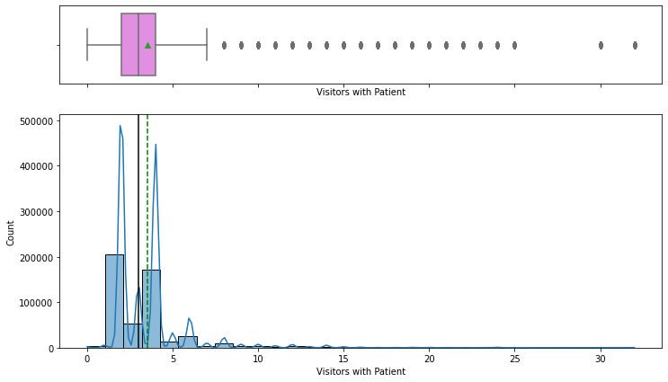

```python
histogram_boxplot(data, "Visitors with Patient", kde=True, bins=30)
```

**Observaciones:**

- La distribución del número de visitantes con el paciente está **muy sesgada hacia la derecha**.
- **2 y 4 son el número más común de visitantes con pacientes.**

### **Análisis bivariado**

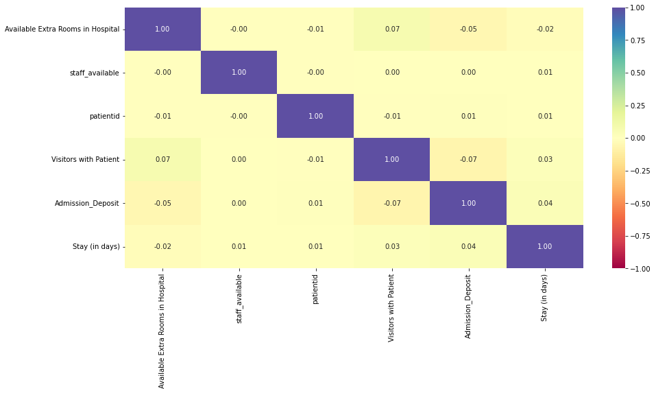

```python
#finding the correlation between various columns of the dataset
import seaborn as sns
import matplotlib.pyplot as plt
plt.figure(figsize=(15,7))
sns.heatmap(data.corr(), annot=True, vmin=-1, vmax=1, fmt=".2f",cmap="Spectral")
```

**Observaciones:**

- El mapa de calor muestra que **no hay correlación entre las variables**.
- Las variables continuas no muestran correlación con la variable objetivo (Estancia (en días)), lo que indica que las **variables categóricas podrían ser más importantes para la predicción.**

```python
# function to plot stacked bar plots


def stacked_barplot(data, predictor, target):
    """
    Print the category counts and plot a stacked bar chart

    data: dataframe
    predictor: independent variable
    target: target variable
    """
    count = data[predictor].nunique()
    sorter = data[target].value_counts().index[-1]
    tab1 = pd.crosstab(data[predictor], data[target], margins=True).sort_values(
        by=sorter, ascending=False
    )
    print(tab1)
    print("-" * 120)
    tab = pd.crosstab(data[predictor], data[target], normalize="index").sort_values(
        by=sorter, ascending=False
    )
    tab.plot(kind="bar", stacked=True, figsize=(count + 1, 5))
    plt.legend(
        loc="lower left",
        frameon=False,
    )
    plt.legend(loc="upper left", bbox_to_anchor=(1, 1))
    plt.show()
```

**Empecemos comprobando la distribución de LOS para los distintos distritos**

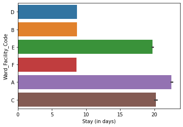

```python
sns.barplot(y = 'Ward_Facility_Code',x = 'Stay (in days)',data = data)
plt.show()
```

**Observaciones:**

- La hipótesis que hicimos anteriormente es correcta, es decir, **las salas A y C tienen a los pacientes alojados durante más tiempo.**

```
Department          TB & Chest disease  anesthesia  gynecology  radiotherapy  \
Ward_Facility_Code
A                                 4709       15611           0         21093
All                              22890       44179      343478         84315
B                                    0           0      103885             0
C                                 1319        4199           0          9079
D                                    0           0      119055             0
E                                16862       24369           0         54143
F                                    0           0      120538             0

Department          surgery     All
Ward_Facility_Code
A                      5138   46551
All                    5138  500000
B                         0  103885
C                         0   14597
D                         0  119055
E                         0   95374
F                         0  120538
------------------------------------------------------------------------------------------------------------------------
```

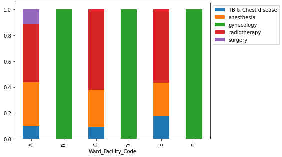

```python
stacked_barplot(data, "Ward_Facility_Code", "Department")
```

**Observaciones:**

- **Las Salas B, D y F están dedicadas únicamente al departamento de ginecología.**
- Las salas A, C y E tienen pacientes con todas las demás enfermedades y los pacientes sometidos a cirugía son admitidos en la sala A únicamente

**Por lo general, cuanto más grave es la enfermedad, mayor es la LOS, revisemos la distribución de pacientes graves en varias salas**

```
Severity of Illness  Extreme   Minor  Moderate     All
Ward_Facility_Code
All                    88266  131537    280197  500000
D                      29549   27220     62286  119055
B                      24222   23579     56084  103885
A                      13662    7877     25012   46551
E                      11488   22254     61632   95374
F                       5842   47594     67102  120538
C                       3503    3013      8081   14597
------------------------------------------------------------------------------------------------------------------------
```

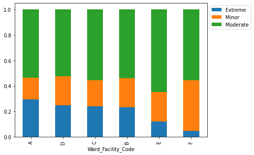

```python
stacked_barplot(data, "Ward_Facility_Code", "Severity of Illness")
```

**Observaciones:**

- El pabellón A tiene el caso más extremo, así como la estadía más prolongada en el hospital. Puede requerir más personal y recursos en comparación con otras salas.
- El pabellón F tiene una gran cantidad de casos menores y el pabellón E tiene una gran cantidad de casos moderados.

**La edad también puede ser un factor importante para determinar la duración de la estadía. Comprobemos lo mismo.**

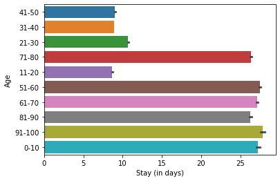

```python
sns.barplot(y = 'Age',x = 'Stay (in days)',data = data )
plt.show()
```

**Observaciones:**

- **Los pacientes con edades entre 1-10 y 51-100 tienden a permanecer la mayor cantidad de días en el hospital.** Esto podría deberse a que la mayoría de los pacientes entre 21-50 años ingresan en el hospital. El departamento de ginecología y los pacientes en los grupos de edad 1-10 y 5-100 pueden ingresar debido a alguna otra enfermedad grave.

## **Preparación de datos para la construcción de modelos**

- Antes de proceder a construir un modelo, tendremos que codificar características categóricas.
- Separar las variables independientes y la Variable dependiente.
- Dividiremos los datos en entrenar y probar para poder evaluar el modelo que entrenamos en los datos de entrenamiento.

```python
# Creating dummy variables for the categorical columns
#drop_first=True is used to avoid redundant variables
data = pd.get_dummies(
    data,
    columns=data.select_dtypes(include=["object", "category"]).columns.tolist(),
    drop_first=True,
)
```

```python
#Check the data, after handling categorical data
data
```

|  | Available Extra Rooms in Hospital | staff_available | patientid | Visitors with Patient | Admission_Deposit | Stay (in days) | Department_anesthesia | Department_gynecology | Department_radiotherapy | Department_surgery | Ward_Facility_Code_B | Ward_Facility_Code_C | Ward_Facility_Code_D | Ward_Facility_Code_E | Ward_Facility_Code_F | doctor_name_Dr John | doctor_name_Dr Mark | doctor_name_Dr Nathan | doctor_name_Dr Olivia | doctor_name_Dr Sam | doctor_name_Dr Sarah | doctor_name_Dr Simon | doctor_name_Dr Sophia | Age_11-20 | Age_21-30 | Age_31-40 | Age_41-50 | Age_51-60 | Age_61-70 | … |
| --- | --- | --- | --- | --- | --- | --- | --- | --- | --- | --- | --- | --- | --- | --- | --- | --- | --- | --- | --- | --- | --- | --- | --- | --- | --- | --- | --- | --- | --- | --- |
| 0 | 4 | 0 | 33070 | 4 | 2966.408696 | 8 | 0 | 1 | 0 | 0 | 0 | 0 | 1 | 0 | 0 | 0 | 0 | 0 | 0 | 0 | 0 | 0 | 1 | 0 | 0 | 0 | 1 | 0 | 0 | … |
| 1 | 4 | 2 | 34808 | 2 | 3554.835677 | 9 | 0 | 1 | 0 | 0 | 1 | 0 | 0 | 0 | 0 | 0 | 0 | 0 | 0 | 0 | 0 | 0 | 1 | 0 | 0 | 1 | 0 | 0 | 0 | … |
| 2 | 2 | 8 | 44577 | 2 | 5624.733654 | 7 | 0 | 1 | 0 | 0 | 1 | 0 | 0 | 0 | 0 | 0 | 0 | 0 | 0 | 0 | 0 | 0 | 1 | 0 | 1 | 0 | 0 | 0 | 0 | … |
| 3 | 4 | 7 | 3695 | 4 | 4814.149231 | 8 | 0 | 1 | 0 | 0 | 0 | 0 | 1 | 0 | 0 | 0 | 0 | 0 | 1 | 0 | 0 | 0 | 0 | 0 | 0 | 1 | 0 | 0 | 0 | … |
| 4 | 2 | 10 | 108956 | 2 | 5169.269637 | 34 | 1 | 0 | 0 | 0 | 0 | 0 | 0 | 1 | 0 | 0 | 1 | 0 | 0 | 0 | 0 | 0 | 0 | 0 | 0 | 0 | 0 | 0 | 0 | … |
| ... | ... | ... | ... | ... | ... | ... | ... | ... | ... | ... | ... | ... | ... | ... | ... | ... | ... | ... | ... | ... | ... | ... | ... | ... | ... | ... | ... | ... | ... | … |
| 499995 | 4 | 2 | 43001 | 3 | 4105.795901 | 10 | 0 | 1 | 0 | 0 | 0 | 0 | 0 | 0 | 1 | 0 | 0 | 0 | 0 | 0 | 1 | 0 | 0 | 1 | 0 | 0 | 0 | 0 | 0 | … |
| 499996 | 13 | 8 | 85601 | 2 | 4631.550257 | 11 | 0 | 1 | 0 | 0 | 0 | 0 | 0 | 0 | 1 | 0 | 0 | 0 | 1 | 0 | 0 | 0 | 0 | 0 | 0 | 1 | 0 | 0 | 0 | … |
| 499997 | 2 | 3 | 22447 | 2 | 5456.930075 | 8 | 0 | 1 | 0 | 0 | 1 | 0 | 0 | 0 | 0 | 0 | 0 | 0 | 0 | 0 | 1 | 0 | 0 | 1 | 0 | 0 | 0 | 0 | 0 | … |
| 499998 | 2 | 1 | 29957 | 2 | 4694.127772 | 23 | 0 | 0 | 1 | 0 | 0 | 0 | 0 | 0 | 0 | 1 | 0 | 0 | 0 | 0 | 0 | 0 | 0 | 0 | 0 | 0 | 0 | 0 | 1 | … |
| 499999 | 3 | 3 | 45008 | 4 | 4713.868519 | 10 | 0 | 1 | 0 | 0 | 0 | 0 | 0 | 0 | 1 | 0 | 0 | 0 | 0 | 0 | 0 | 0 | 1 | 0 | 0 | 0 | 1 | 0 | 0 | … |

500000 rows × 44 columns

```python
#Dropping patientid from the data as it is an identifier and will not add value to the analysis
data=data.drop(columns=["patientid"])
```

```python
#Separating independent variables and the target variable
x=data.drop('Stay (in days)',axis=1)

y=data['Stay (in days)']
```

```python
#Splitting the dataset into train and test datasets
x_train,x_test,y_train,y_test=train_test_split(x,y,test_size=0.2,shuffle=True,random_state=1)
```

```python
#Checking the shape of the train and test data
print("Shape of Training set : ", x_train.shape)
print("Shape of test set : ", x_test.shape)
```

```
Shape of Training set :  (400000, 42)
Shape of test set :  (100000, 42)
```

## **Construcción de modelos**

- Usaremos diferentes funciones métricas definidas en sklearn como RMSE, MAE y 𝑅2 para la evaluación de modelos de regresión.
- Definiremos una función para calcular MAPE y 𝑅2 ajustado.
- El error porcentual absoluto medio (MAPE) mide la precisión de las predicciones como un porcentaje y se puede calcular como el error porcentual absoluto medio para cada valor predicho menos los valores reales divididos por los valores reales. Funciona mejor si no hay valores extremos en los datos y ninguno de los valores reales es 0.

```python
# function to compute adjusted R-squared
def adj_r2_score(predictors, targets, predictions):
    r2 = r2_score(targets, predictions)
    n = predictors.shape[0]
    k = predictors.shape[1]
    return 1 - ((1 - r2) * (n - 1) / (n - k - 1))


# function to compute MAPE
def mape_score(targets, predictions):
    return np.mean(np.abs(targets - predictions) / targets) * 100


# function to compute different metrics to check performance of a regression model
def model_performance_regression(model, predictors, target):
    """
    Function to compute different metrics to check regression model performance

    model: regressor
    predictors: independent variables
    target: dependent variable
    """

    # predicting using the independent variables
    pred = model.predict(predictors)

    r2 = r2_score(target, pred)  # to compute R-squared
    adjr2 = adj_r2_score(predictors, target, pred)  # to compute adjusted R-squared
    rmse = np.sqrt(mean_squared_error(target, pred))  # to compute RMSE
    mae = mean_absolute_error(target, pred)  # to compute MAE
    mape = mape_score(target, pred)  # to compute MAPE

    # creating a dataframe of metrics
    df_perf = pd.DataFrame(
        {
            "RMSE": rmse,
            "MAE": mae,
            "R-squared": r2,
            "Adj. R-squared": adjr2,
            "MAPE": mape,
        },
        index=[0],
    )

    return df_perf
```

```python
# RMSE
def rmse(predictions, targets):
    return np.sqrt(((targets - predictions) ** 2).mean())


# MAPE
def mape(predictions, targets):
    return np.mean(np.abs((targets - predictions)) / targets) * 100


# MAE
def mae(predictions, targets):
    return np.mean(np.abs((targets - predictions)))


# Model Performance on test and train data
def model_pref(olsmodel, x_train, x_test, y_train,y_test):

    # Insample Prediction
    y_pred_train = olsmodel.predict(x_train)
    y_observed_train = y_train

    # Prediction on test data
    y_pred_test = olsmodel.predict(x_test)
    y_observed_test = y_test

    print(
        pd.DataFrame(
            {
                "Data": ["Train", "Test"],
                "RMSE": [
                    rmse(y_pred_train, y_observed_train),
                    rmse(y_pred_test, y_observed_test),
                ],
                "MAE": [
                    mae(y_pred_train, y_observed_train),
                    mae(y_pred_test, y_observed_test),
                ],
                "MAPE": [
                    mape(y_pred_train, y_observed_train),
                    mape(y_pred_test, y_observed_test),
                ],
            }
        )
    )
```

```python
import statsmodels.api as sm

# Statsmodel api does not add a constant by default. We need to add it explicitly.
x_train1 = sm.add_constant(x_train)
# Add constant to test data
x_test1 = sm.add_constant(x_test)

# create the model
olsmodel1 = sm.OLS(y_train, x_train1).fit()

# get the model summary
olsmodel1.summary()
print(olsmodel1.summary())
```

```
                            OLS Regression Results
==============================================================================
Dep. Variable:         Stay (in days)   R-squared:                       0.843
Model:                            OLS   Adj. R-squared:                  0.843
Method:                 Least Squares   F-statistic:                 5.643e+04
Date:                Fri, 25 Mar 2022   Prob (F-statistic):               0.00
Time:                        12:09:56   Log-Likelihood:            -1.0246e+06
No. Observations:              400000   AIC:                         2.049e+06
Df Residuals:                  399961   BIC:                         2.050e+06
Df Model:                          38
Covariance Type:            nonrobust
=========================================================================================================
                                            coef    std err          t      P>|t|      [0.025      0.975]
---------------------------------------------------------------------------------------------------------
const                                    19.8918      0.055    359.659      0.000      19.783      20.000
Available Extra Rooms in Hospital         0.0786      0.002     42.311      0.000       0.075       0.082
staff_available                          -0.0009      0.002     -0.588      0.557      -0.004       0.002
Visitors with Patient                     0.0002      0.002      0.099      0.921      -0.004       0.005
Admission_Deposit                     -3.839e-05   4.78e-06     -8.029      0.000   -4.78e-05    -2.9e-05
Department_anesthesia                     6.0823      0.029    210.110      0.000       6.026       6.139
Department_gynecology                     0.4635      0.019     24.149      0.000       0.426       0.501
Department_radiotherapy                  -4.6217      0.037   -126.135      0.000      -4.693      -4.550
Department_surgery                        9.6867      0.044    218.475      0.000       9.600       9.774
Ward_Facility_Code_B                      0.2571      0.011     23.468      0.000       0.236       0.279
Ward_Facility_Code_C                      0.4349      0.035     12.604      0.000       0.367       0.503
Ward_Facility_Code_D                      0.2033      0.011     19.313      0.000       0.183       0.224
Ward_Facility_Code_E                      0.3087      0.021     14.409      0.000       0.267       0.351
Ward_Facility_Code_F                      0.0031      0.011      0.282      0.778      -0.018       0.025
doctor_name_Dr John                       7.2631      0.031    232.919      0.000       7.202       7.324
doctor_name_Dr Mark                       1.1949      0.033     36.394      0.000       1.131       1.259
doctor_name_Dr Nathan                    -0.2164      0.017    -12.662      0.000      -0.250      -0.183
doctor_name_Dr Olivia                    -0.3620      0.016    -22.985      0.000      -0.393      -0.331
doctor_name_Dr Sam                        1.2836      0.038     33.875      0.000       1.209       1.358
doctor_name_Dr Sarah                      0.8252      0.020     41.740      0.000       0.786       0.864
doctor_name_Dr Simon                      6.1602      0.069     89.051      0.000       6.025       6.296
doctor_name_Dr Sophia                     0.2167      0.020     10.605      0.000       0.177       0.257
Age_11-20                               -12.7378      0.065   -194.584      0.000     -12.866     -12.609
Age_21-30                               -10.4830      0.062   -168.463      0.000     -10.605     -10.361
Age_31-40                               -13.4354      0.062   -216.955      0.000     -13.557     -13.314
Age_41-50                               -13.5113      0.062   -216.833      0.000     -13.633     -13.389
```

[output cut: 13 more lines]

```
health_conditions_High Blood Pressure    -0.0317      0.019     -1.666      0.096      -0.069       0.006
health_conditions_None                    0.0140      0.024      0.576      0.565      -0.034       0.062
health_conditions_Other                   0.0186      0.025      0.735      0.463      -0.031       0.068
Insurance_Yes                            -0.0108      0.012     -0.889      0.374      -0.035       0.013
==============================================================================
Omnibus:                   131769.068   Durbin-Watson:                   1.998
Prob(Omnibus):                  0.000   Jarque-Bera (JB):           708961.811
Skew:                           1.495   Prob(JB):                         0.00
Kurtosis:                       8.796   Cond. No.                     1.03e+16
==============================================================================

Warnings:
[1] Standard Errors assume that the covariance matrix of the errors is correctly specified.
[2] The smallest eigenvalue is 8.91e-20. This might indicate that there are
strong multicollinearity problems or that the design matrix is singular.
```

```python
lin_reg_test = model_performance_regression(olsmodel1, x_test1, y_test)
lin_reg_test
```

|  | RMSE | MAE | R-squared | Adj. R-squared | MAPE |
| --- | --- | --- | --- | --- | --- |
| 0 | 3.144036 | 2.155759 | 0.84303 | 0.842962 | 19.676874 |

- Podemos ver que `R-squared` para el modelo es `0.84`.
- No todas las variables son lo suficientemente significativas estadísticamente para predecir la variable resultado. Para verificar cuáles son estadísticamente significativos o tienen suficiente poder predictivo para predecir la variable objetivo, debemos verificar el "valor p" con todas las variables independientes.

**Interpretación de los resultados de la regresión:**

1. **R-cuadrado ajustado**: Refleja el ajuste del modelo.
   - Los valores de R-cuadrado van de 0 a 1, donde un valor más alto generalmente indica un mejor ajuste, suponiendo que se cumplan ciertas condiciones.
   - En nuestro caso, el valor de Adj. R-cuadrado es **0.84**
2. **coef**: Representa el cambio en la salida Y debido a un cambio de una unidad en la variable (todo lo demás se mantiene constante).
3. **std err**: Refleja el nivel de precisión de los coeficientes.
   - Cuanto más bajo es, más precisos son los coeficientes.
4. **P > |t|**: El valor p:
   - Pr(>|t|) : Para cada característica independiente hay una hipótesis nula y una hipótesis alternativa
     - **Ho:**Hipótesis nula - La característica independiente no es significativa
     - **Ha:**Hipótesis alternativa - La característica independiente es significativa* Un valor de p inferior a 0.05 se considera estadísticamente significativo.
1. **Intervalo de confianza**: Representa el rango en el que es probable que caigan nuestros coeficientes (con una probabilidad del 95%).
- Tanto el **R-cuadrado como el R-cuadrado ajustado del modelo están alrededor del 84 %**. Esta es una clara indicación de que hemos sido capaces de crear un buen modelo que puede explicar la variación en la LOS de los pacientes hasta en un 84 %.
- Podemos examinar la importancia del modelo de regresión e intentar descartar variables insignificantes.

```python
model_pref(olsmodel1, x_train1, x_test1,y_train,y_test)
```

```
    Data      RMSE       MAE       MAPE
0  Train  3.135092  2.146240  19.591781
1   Test  3.144036  2.155759  19.676874
```

**El error cuadrático medio de la raíz** de los datos de entrenamiento y prueba es **no diferente**, lo que indica que **nuestro modelo no se está sobreajustando** a los datos de entrenamiento.

El error absoluto medio (MAE) indica que nuestro modelo actual es capaz de predecir la LOS de los pacientes dentro de **error medio de 2,15 días** en los datos de prueba.

Las unidades de RMSE y MAE son las mismas, días en este caso. Pero RMSE es mayor que MAE porque penaliza más a los valores atípicos.

**El error porcentual absoluto medio es ~19 %** en los datos de prueba.

### Comprobación de multicolinealidad

Usaremos VIF, para comprobar si hay multicolinealidad en los datos.

Las funciones que tengan una puntuación VIF > 5 se eliminarán/se tratarán hasta que todas las funciones tengan una puntuación VIF < 5

```python
from statsmodels.stats.outliers_influence import variance_inflation_factor


def checking_vif(train):
    vif = pd.DataFrame()
    vif["feature"] = train.columns

    # calculating VIF for each feature
    vif["VIF"] = [
        variance_inflation_factor(train.values, i) for i in range(len(train.columns))
    ]
    return vif
```

```python
print(checking_vif(x_train1))
```

```
                                  feature        VIF
0                                   const   0.000000
1       Available Extra Rooms in Hospital   1.023190
2                         staff_available   1.001928
3                   Visitors with Patient   1.029237
4                       Admission_Deposit   1.021080
5                   Department_anesthesia   2.737559
6                   Department_gynecology        inf
7                 Department_radiotherapy   7.650821
8                      Department_surgery        inf
9                    Ward_Facility_Code_B        inf
10                   Ward_Facility_Code_C   1.366866
11                   Ward_Facility_Code_D        inf
12                   Ward_Facility_Code_E   2.880783
13                   Ward_Facility_Code_F        inf
```

[output cut: 29 more lines]

```python
# create the model
olsmodel1 = sm.OLS(y_train, x_train1).fit()

# get the model summary
olsmodel1.summary()
```

OLS Regression Results

| Dep. Variable: | Stay (in days) | R-squared: | 0.843 |
| --- | --- | --- | --- |
| Model: | OLS | Adj. R-squared: | 0.843 |
| Method: | Least Squares | F-statistic: | 5.643e+04 |
| Date: | Fri, 25 Mar 2022 | Prob (F-statistic): | 0.00 |
| Time: | 12:11:58 | Log-Likelihood: | -1.0246e+06 |
| No. Observations: | 400000 | AIC: | 2.049e+06 |
| Df Residuals: | 399961 | BIC: | 2.050e+06 |
| Df Model: | 38 |  |  |
| Covariance Type: | nonrobust |  |  |

|  | coef | std err | t | P>\|t\| | [0.025 | 0.975] |
| --- | --- | --- | --- | --- | --- | --- |
| const | 19.8918 | 0.055 | 359.659 | 0.000 | 19.783 | 20.000 |
| Available Extra Rooms in Hospital | 0.0786 | 0.002 | 42.311 | 0.000 | 0.075 | 0.082 |
| staff_available | -0.0009 | 0.002 | -0.588 | 0.557 | -0.004 | 0.002 |
| Visitors with Patient | 0.0002 | 0.002 | 0.099 | 0.921 | -0.004 | 0.005 |
| Admission_Deposit | -3.839e-05 | 4.78e-06 | -8.029 | 0.000 | -4.78e-05 | -2.9e-05 |
| Department_anesthesia | 6.0823 | 0.029 | 210.110 | 0.000 | 6.026 | 6.139 |
| Department_gynecology | 0.4635 | 0.019 | 24.149 | 0.000 | 0.426 | 0.501 |
| Department_radiotherapy | -4.6217 | 0.037 | -126.135 | 0.000 | -4.693 | -4.550 |
| Department_surgery | 9.6867 | 0.044 | 218.475 | 0.000 | 9.600 | 9.774 |
| Ward_Facility_Code_B | 0.2571 | 0.011 | 23.468 | 0.000 | 0.236 | 0.279 |
| Ward_Facility_Code_C | 0.4349 | 0.035 | 12.604 | 0.000 | 0.367 | 0.503 |
| Ward_Facility_Code_D | 0.2033 | 0.011 | 19.313 | 0.000 | 0.183 | 0.224 |
| Ward_Facility_Code_E | 0.3087 | 0.021 | 14.409 | 0.000 | 0.267 | 0.351 |
| Ward_Facility_Code_F | 0.0031 | 0.011 | 0.282 | 0.778 | -0.018 | 0.025 |
| doctor_name_Dr John | 7.2631 | 0.031 | 232.919 | 0.000 | 7.202 | 7.324 |
| doctor_name_Dr Mark | 1.1949 | 0.033 | 36.394 | 0.000 | 1.131 | 1.259 |
| doctor_name_Dr Nathan | -0.2164 | 0.017 | -12.662 | 0.000 | -0.250 | -0.183 |
| doctor_name_Dr Olivia | -0.3620 | 0.016 | -22.985 | 0.000 | -0.393 | -0.331 |
| doctor_name_Dr Sam | 1.2836 | 0.038 | 33.875 | 0.000 | 1.209 | 1.358 |
| doctor_name_Dr Sarah | 0.8252 | 0.020 | 41.740 | 0.000 | 0.786 | 0.864 |
| doctor_name_Dr Simon | 6.1602 | 0.069 | 89.051 | 0.000 | 6.025 | 6.296 |
| doctor_name_Dr Sophia | 0.2167 | 0.020 | 10.605 | 0.000 | 0.177 | 0.257 |
| Age_11-20 | -12.7378 | 0.065 | -194.584 | 0.000 | -12.866 | -12.609 |
| Age_21-30 | -10.4830 | 0.062 | -168.463 | 0.000 | -10.605 | -10.361 |
| Age_31-40 | -13.4354 | 0.062 | -216.955 | 0.000 | -13.557 | -13.314 |
| Age_41-50 | -13.5113 | 0.062 | -216.833 | 0.000 | -13.633 | -13.389 |
| Age_51-60 | -0.3664 | 0.065 | -5.649 | 0.000 | -0.494 | -0.239 |
| Age_61-70 | -0.4217 | 0.064 | -6.591 | 0.000 | -0.547 | -0.296 |
| Age_71-80 | -0.2193 | 0.066 | -3.342 | 0.001 | -0.348 | -0.091 |
| Age_81-90 | -0.0174 | 0.072 | -0.242 | 0.809 | -0.158 | 0.123 |
| Age_91-100 | -0.2599 | 0.112 | -2.323 | 0.020 | -0.479 | -0.041 |
| gender_Male | 6.0050 | 0.038 | 156.967 | 0.000 | 5.930 | 6.080 |
| gender_Other | -0.0257 | 0.030 | -0.846 | 0.398 | -0.085 | 0.034 |
| Type of Admission_Trauma | -0.0669 | 0.012 | -5.640 | 0.000 | -0.090 | -0.044 |
| Type of Admission_Urgent | 0.1500 | 0.018 | 8.292 | 0.000 | 0.115 | 0.185 |
| Severity of Illness_Minor | 0.0418 | 0.016 | 2.547 | 0.011 | 0.010 | 0.074 |
| Severity of Illness_Moderate | 0.0967 | 0.016 | 5.980 | 0.000 | 0.065 | 0.128 |
| health_conditions_Diabetes | -0.3422 | 0.028 | -12.150 | 0.000 | -0.397 | -0.287 |
| health_conditions_Heart disease | 0.6037 | 0.032 | 19.033 | 0.000 | 0.542 | 0.666 |
| health_conditions_High Blood Pressure | -0.0317 | 0.019 | -1.666 | 0.096 | -0.069 | 0.006 |
| health_conditions_None | 0.0140 | 0.024 | 0.576 | 0.565 | -0.034 | 0.062 |
| health_conditions_Other | 0.0186 | 0.025 | 0.735 | 0.463 | -0.031 | 0.068 |
| Insurance_Yes | -0.0108 | 0.012 | -0.889 | 0.374 | -0.035 | 0.013 |

| Omnibus: | 131769.068 | Durbin-Watson: | 1.998 |
| --- | --- | --- | --- |
| Prob(Omnibus): | 0.000 | Jarque-Bera (JB): | 708961.811 |
| Skew: | 1.495 | Prob(JB): | 0.00 |
| Kurtosis: | 8.796 | Cond. No. | 1.03e+16 |

Warnings:  
[1] Standard Errors assume that the covariance matrix of the errors is correctly specified.  
[2] The smallest eigenvalue is 8.91e-20. This might indicate that there are  
strong multicollinearity problems or that the design matrix is singular.

No es una buena práctica considerar valores de VIF para variables ficticias, ya que están correlacionadas con otras categorías y, por lo tanto, generalmente tienen un VIF alto. Así que construimos el modelo y calculamos los valores p. Podemos ver que las categorías en la columna `Insurace_Yes` muestran un valor de p superior a 0.05. Así que podemos dejar eso.

```python
x_train2 = x_train1.drop(['Insurance_Yes','staff_available','Visitors with Patient'] , axis=1)
print(checking_vif(x_train2))
```

```
                                  feature        VIF
0                                   const   0.000000
1       Available Extra Rooms in Hospital   1.019576
2                       Admission_Deposit   1.017145
3                   Department_anesthesia   2.736471
4                   Department_gynecology        inf
5                 Department_radiotherapy   7.646203
6                      Department_surgery        inf
7                    Ward_Facility_Code_B        inf
8                    Ward_Facility_Code_C   1.366194
9                    Ward_Facility_Code_D        inf
10                   Ward_Facility_Code_E   2.866845
11                   Ward_Facility_Code_F        inf
12                    doctor_name_Dr John        inf
13                    doctor_name_Dr Mark        inf
```

[output cut: 26 more lines]

## **Descartando las variables insignificantes y creando de nuevo el modelo de regresión**

### **Examinando la importancia del modelo**

No basta con ajustar un modelo de regresión múltiple a los datos, también es necesario comprobar si todos los coeficientes de regresión son significativos o no. Significancia aquí significa si los parámetros de regresión de población son significativamente diferentes de cero.

De lo anterior se puede notar que los coeficientes de regresión correspondientes a 'Insurance_Yes','staff_available' y 'Visitors with Patient' **no son estadísticamente significativos al nivel α = 0.05.** En otras palabras, los coeficientes de regresión correspondientes a estos tres no son significativamente diferentes de 0 en la población.

Suponga que tiene una variable categórica nominal que tiene 4 categorías (o niveles). Crearía 3 variables ficticias (k-1 = 4-1 variables ficticias) y establecería una categoría como nivel de referencia. Supongamos que uno de ellos es insignificante. Entonces, si excluye esa variable ficticia, cambiaría el nivel de referencia ya que está combinando indirectamente ese nivel insignificante con el nivel de referencia original. Tendría un nuevo nivel de referencia y la interpretación cambiaría. Además, excluir el nivel puede hacer que los demás sean insignificantes. Si todas las categorías en una columna muestran un valor p superior a 0,05, podemos descartarlo.

**Por lo tanto, eliminaremos estas tres características y crearemos un nuevo modelo.**

```python
# create the model after dropping variables
x_train2 = x_train1.drop(['Insurance_Yes','staff_available','Visitors with Patient'] , axis=1)
x_test2 = x_test1.drop(['Insurance_Yes','staff_available','Visitors with Patient'] , axis=1)
# create the model
olsmodel2 = sm.OLS(y_train, x_train2).fit()
# get the model summary
olsmodel2.summary()
```

OLS Regression Results

| Dep. Variable: | Stay (in days) | R-squared: | 0.843 |
| --- | --- | --- | --- |
| Model: | OLS | Adj. R-squared: | 0.843 |
| Method: | Least Squares | F-statistic: | 6.127e+04 |
| Date: | Fri, 25 Mar 2022 | Prob (F-statistic): | 0.00 |
| Time: | 12:13:46 | Log-Likelihood: | -1.0246e+06 |
| No. Observations: | 400000 | AIC: | 2.049e+06 |
| Df Residuals: | 399964 | BIC: | 2.050e+06 |
| Df Model: | 35 |  |  |
| Covariance Type: | nonrobust |  |  |

|  | coef | std err | t | P>\|t\| | [0.025 | 0.975] |
| --- | --- | --- | --- | --- | --- | --- |
| const | 19.8830 | 0.054 | 367.192 | 0.000 | 19.777 | 19.989 |
| Available Extra Rooms in Hospital | 0.0786 | 0.002 | 42.392 | 0.000 | 0.075 | 0.082 |
| Admission_Deposit | -3.843e-05 | 4.77e-06 | -8.052 | 0.000 | -4.78e-05 | -2.91e-05 |
| Department_anesthesia | 6.0823 | 0.029 | 210.151 | 0.000 | 6.026 | 6.139 |
| Department_gynecology | 0.4614 | 0.019 | 24.233 | 0.000 | 0.424 | 0.499 |
| Department_radiotherapy | -4.6218 | 0.037 | -126.176 | 0.000 | -4.694 | -4.550 |
| Department_surgery | 9.6845 | 0.044 | 218.840 | 0.000 | 9.598 | 9.771 |
| Ward_Facility_Code_B | 0.2563 | 0.011 | 23.447 | 0.000 | 0.235 | 0.278 |
| Ward_Facility_Code_C | 0.4350 | 0.034 | 12.612 | 0.000 | 0.367 | 0.503 |
| Ward_Facility_Code_D | 0.2027 | 0.010 | 19.348 | 0.000 | 0.182 | 0.223 |
| Ward_Facility_Code_E | 0.3088 | 0.021 | 14.447 | 0.000 | 0.267 | 0.351 |
| Ward_Facility_Code_F | 0.0024 | 0.011 | 0.223 | 0.823 | -0.019 | 0.024 |
| doctor_name_Dr John | 7.2605 | 0.031 | 234.529 | 0.000 | 7.200 | 7.321 |
| doctor_name_Dr Mark | 1.1939 | 0.033 | 36.405 | 0.000 | 1.130 | 1.258 |
| doctor_name_Dr Nathan | -0.2169 | 0.017 | -12.700 | 0.000 | -0.250 | -0.183 |
| doctor_name_Dr Olivia | -0.3626 | 0.016 | -23.037 | 0.000 | -0.393 | -0.332 |
| doctor_name_Dr Sam | 1.2826 | 0.038 | 33.877 | 0.000 | 1.208 | 1.357 |
| doctor_name_Dr Sarah | 0.8247 | 0.020 | 41.732 | 0.000 | 0.786 | 0.863 |
| doctor_name_Dr Simon | 6.1584 | 0.069 | 89.079 | 0.000 | 6.023 | 6.294 |
| doctor_name_Dr Sophia | 0.2162 | 0.020 | 10.583 | 0.000 | 0.176 | 0.256 |
| Age_11-20 | -12.7379 | 0.065 | -194.592 | 0.000 | -12.866 | -12.610 |
| Age_21-30 | -10.4831 | 0.062 | -168.470 | 0.000 | -10.605 | -10.361 |
| Age_31-40 | -13.4355 | 0.062 | -216.958 | 0.000 | -13.557 | -13.314 |
| Age_41-50 | -13.5114 | 0.062 | -216.834 | 0.000 | -13.633 | -13.389 |
| Age_51-60 | -0.3665 | 0.065 | -5.651 | 0.000 | -0.494 | -0.239 |
| Age_61-70 | -0.4217 | 0.064 | -6.592 | 0.000 | -0.547 | -0.296 |
| Age_71-80 | -0.2193 | 0.066 | -3.343 | 0.001 | -0.348 | -0.091 |
| Age_81-90 | -0.0174 | 0.072 | -0.243 | 0.808 | -0.158 | 0.123 |
| Age_91-100 | -0.2600 | 0.112 | -2.323 | 0.020 | -0.479 | -0.041 |
| gender_Male | 6.0026 | 0.038 | 157.336 | 0.000 | 5.928 | 6.077 |
| gender_Other | -0.0258 | 0.030 | -0.849 | 0.396 | -0.085 | 0.034 |
| Type of Admission_Trauma | -0.0669 | 0.012 | -5.639 | 0.000 | -0.090 | -0.044 |
| Type of Admission_Urgent | 0.1500 | 0.018 | 8.293 | 0.000 | 0.115 | 0.185 |
| Severity of Illness_Minor | 0.0418 | 0.016 | 2.547 | 0.011 | 0.010 | 0.074 |
| Severity of Illness_Moderate | 0.0968 | 0.016 | 5.983 | 0.000 | 0.065 | 0.128 |
| health_conditions_Diabetes | -0.3421 | 0.028 | -12.149 | 0.000 | -0.397 | -0.287 |
| health_conditions_Heart disease | 0.6043 | 0.032 | 19.057 | 0.000 | 0.542 | 0.666 |
| health_conditions_High Blood Pressure | -0.0321 | 0.019 | -1.685 | 0.092 | -0.069 | 0.005 |
| health_conditions_None | 0.0136 | 0.024 | 0.561 | 0.575 | -0.034 | 0.061 |
| health_conditions_Other | 0.0185 | 0.025 | 0.730 | 0.465 | -0.031 | 0.068 |

| Omnibus: | 131768.365 | Durbin-Watson: | 1.998 |
| --- | --- | --- | --- |
| Prob(Omnibus): | 0.000 | Jarque-Bera (JB): | 708957.590 |
| Skew: | 1.495 | Prob(JB): | 0.00 |
| Kurtosis: | 8.796 | Cond. No. | 1.03e+16 |

Warnings:  
[1] Standard Errors assume that the covariance matrix of the errors is correctly specified.  
[2] The smallest eigenvalue is 8.91e-20. This might indicate that there are  
strong multicollinearity problems or that the design matrix is singular.

```python
lin_reg_test = model_performance_regression(olsmodel2, x_test2, y_test)
lin_reg_test
```

|  | RMSE | MAE | R-squared | Adj. R-squared | MAPE |
| --- | --- | --- | --- | --- | --- |
| 0 | 3.144035 | 2.155757 | 0.84303 | 0.842967 | 19.676878 |

### **Comprobación del rendimiento del modelo en el conjunto de datos de prueba y entrenamiento**

```python
model_pref(olsmodel2, x_train2, x_test2,y_train,y_test)
```

```
    Data      RMSE       MAE       MAPE
0  Train  3.135096  2.146234  19.591646
1   Test  3.144035  2.155757  19.676878
```

**Observaciones:**

- RMSE, MAE y MAPE de los datos del entrenamiento y de la prueba no son muy diferentes, lo que indica que el **modelo no se sobreajusta y se ha generalizado bien.**

## **Comprobación de suposiciones y reconstrucción del modelo**

En este paso, verificaremos las siguientes suposiciones en el modelo, para verificar si son ciertas o no. Y si hay algún problema, reconstruiremos el modelo después de solucionar esos problemas.

1. La media de los residuos debe ser 0
2. Sin heterocedasticidad
3. Linealidad de las variables
4. Normalidad de los términos de error

### **La media de los residuos debe ser 0 y la normalidad de los términos de error**

```python
residual = olsmodel2.resid # Residuals
```

```python
residual.mean()
```

```
-7.234585683857375e-12
```

La media de los residuos es muy cercana a 0. Por tanto, se cumple la hipótesis correspondiente.

## **Pruebas de normalidad**

**¿Qué es la prueba?**

- Los términos de error/residuales deben distribuirse normalmente
- Si los términos de error no se distribuyen normalmente, los intervalos de confianza pueden volverse demasiado anchos o estrechos. Una vez que el intervalo de confianza se vuelve inestable, genera dificultades para estimar los coeficientes basados en la minimización de los mínimos cuadrados.

**¿Qué indica la no normalidad?**

- Sugiere que hay algunos puntos de datos inusuales que deben estudiarse de cerca para hacer un mejor modelo.

**¿Cómo comprobar la normalidad?**

- Se puede comprobar a través de QQ Plot. Los residuos que siguen una distribución normal formarán un gráfico de línea recta, de lo contrario no.
- Otra prueba para comprobar la normalidad: prueba de Shapiro-Wilk.

**¿Qué son los residuos no normales?**

- Podemos aplicar transformaciones como logaritmo, exponencial, arcsinh, etc. según nuestros datos

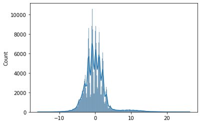

```python
# Plot histogram of residuals
sns.histplot(residual, kde=True)
```

### **Linealidad de Variables**

Establece que las variables predictoras deben tener una relación lineal con la variable dependiente.

Para probar la suposición, representaremos los residuos y los valores ajustados en un gráfico y nos aseguraremos de que los residuos no formen un patrón fuerte. Deben estar dispersos aleatoria y uniformemente en el eje x.

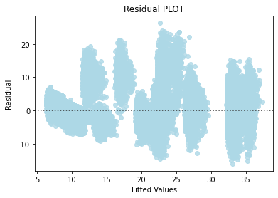

```python
# predicted values
fitted = olsmodel2.fittedvalues

# sns.set_style("whitegrid")
sns.residplot(x = fitted, y = residual, color="lightblue")
plt.xlabel("Fitted Values")
plt.ylabel("Residual")
plt.title("Residual PLOT")
plt.show()
```

**Observaciones**

Comprobemos la suposición final.

### **Sin heterocedasticidad**

#### **Prueba de homocedasticidad**

- **Homocedasticidad -**Si la varianza de los residuos se distribuye simétricamente a lo largo de la línea de regresión, entonces se dice que los datos son homocedásticos.
- **Heteroscedasticidad -** Si la varianza es desigual para los residuos a lo largo de la línea de regresión, entonces se dice que los datos son heteroscedásticos. En este caso, los residuos pueden tener forma de flecha o cualquier otra forma no simétrica.

Usaremos la prueba de Goldfeld-Quandt para verificar la homocedasticidad.

Hipótesis nula: los residuos son homocedásticos

Hipótesis alternativa: los residuos son heteroscedásticos

alfa = 0.05

```python
import statsmodels.stats.api as sms
from statsmodels.compat import lzip

name = ["F statistic", "p-value"]
test = sms.het_goldfeldquandt(residual, x_train2)
lzip(name, test)
```

```
[('F statistic', 1.0039106858288322), ('p-value', 0.19142132359756808)]
```

Como podemos ver en la prueba anterior, el valor p es mayor que 0.05, por lo que no podemos rechazar la hipótesis nula. Eso significa que los residuos son homocedásticos.

```python
coef = olsmodel2.params
coef
```

```
const                                    19.882991
Available Extra Rooms in Hospital         0.078613
Admission_Deposit                        -0.000038
Department_anesthesia                     6.082290
Department_gynecology                     0.461435
Department_radiotherapy                  -4.621785
Department_surgery                        9.684522
Ward_Facility_Code_B                      0.256348
Ward_Facility_Code_C                      0.435039
Ward_Facility_Code_D                      0.202650
Ward_Facility_Code_E                      0.308803
Ward_Facility_Code_F                      0.002437
doctor_name_Dr John                       7.260505
doctor_name_Dr Mark                       1.193884
doctor_name_Dr Nathan                    -0.216913
doctor_name_Dr Olivia                    -0.362561
doctor_name_Dr Sam                        1.282646
doctor_name_Dr Sarah                      0.824732
doctor_name_Dr Simon                      6.158436
doctor_name_Dr Sophia                     0.216177
Age_11-20                               -12.737857
Age_21-30                               -10.483087
Age_31-40                               -13.435474
Age_41-50                               -13.511366
Age_51-60                                -0.366511
Age_61-70                                -0.421711
Age_71-80                                -0.219299
Age_81-90                                -0.017441
Age_91-100                               -0.259979
gender_Male                               6.002615
gender_Other                             -0.025828
Type of Admission_Trauma                 -0.066864
Type of Admission_Urgent                  0.150018
Severity of Illness_Minor                 0.041827
Severity of Illness_Moderate              0.096762
health_conditions_Diabetes               -0.342149
health_conditions_Heart disease           0.604331
health_conditions_High Blood Pressure    -0.032053
health_conditions_None                    0.013627
health_conditions_Other                   0.018478
dtype: float64
```

```python
# Let us write the equation of the fit
Equation = "Stay (in days)="
print(Equation, end='\t')
for i in range(len(coef)):
    print('(', coef[i], ') * ', coef.index[i], '+', end = ' ')
```

```
Stay (in days)=	( 19.882990782603567 ) *  const + ( 0.07861348628795 ) *  Available Extra Rooms in Hospital + ( -3.842950953302121e-05 ) *  Admission_Deposit + ( 6.082290257916215 ) *  Department_anesthesia + ( 0.46143468993964865 ) *  Department_gynecology + ( -4.621785263664272 ) *  Department_rad…
```

### **Interpretación de nuestros coeficientes de regresión**

Con el valor R cuadrado ajustado de nuestro modelo de regresión lineal de alrededor de 0.84, podemos capturar **84 % de la variación** en nuestros datos.

Los valores de p para estas variables son < 0.05 en nuestro modelo final, lo que significa que son estadísticamente significativos para la predicción de estancia (en días).

### **Aplicar la técnica de validación cruzada para mejorar el modelo y evaluarlo utilizando diferentes métricas de evaluación**

```python
# import the required function
from sklearn.model_selection import cross_val_score

# build the regression model using Sklearn Linear regression
linearregression = LinearRegression()

cv_Score11 = cross_val_score(linearregression, x_train2, y_train, cv = 10) #cv=10 represents data is divided into 10 folds.
cv_Score12 = cross_val_score(linearregression, x_train2, y_train, cv = 10,
                             scoring = 'neg_mean_squared_error')


print("RSquared: %0.3f (+/- %0.3f)" % (cv_Score11.mean(), cv_Score11.std() * 2))
print("Mean Squared Error: %0.3f (+/- %0.3f)" % (-1*cv_Score12.mean(), cv_Score12.std() * 2))
```

```
RSquared: 0.843 (+/- 0.004)
Mean Squared Error: 9.831 (+/- 0.296)
```

**Observaciones:**

- El R-cuadrado en la validación cruzada es 0,843, mientras que en el conjunto de datos de entrenamiento fue 0,843
- Y el MSE en la validación cruzada es 9.831, mientras que en el conjunto de datos de entrenamiento también fue 9.83

Es posible que deseemos reiterar el proceso de creación de modelos nuevamente con nuevas funciones o una mejor ingeniería de funciones para aumentar el R-cuadrado y disminuir el MSE en la validación cruzada.

### **Regresión de cresta**

```python
rdg = Ridge()
```

```python
rdg.fit(x_train, y_train)
model_pref(rdg, x_train, x_test,y_train,y_test)
```

```
    Data      RMSE       MAE       MAPE
0  Train  3.135092  2.146301  19.592776
1   Test  3.144039  2.155819  19.677875
```

```python
ridge_regression_perf_test = model_performance_regression(rdg, x_test, y_test)

ridge_regression_perf_test
```

|  | RMSE | MAE | R-squared | Adj. R-squared | MAPE |
| --- | --- | --- | --- | --- | --- |
| 0 | 3.144039 | 2.155819 | 0.84303 | 0.842964 | 19.677875 |

La regresión de cresta puede producir resultados similares en comparación con la regresión lineal.

Definitivamente hay algo de margen para mejorar el rendimiento del modelo, ya que existe la sensación de que no podemos modelar completamente la relación usando modelos lineales.

Ahora construyamos **modelos de regresión no lineal** como regresores de árbol de decisión y regresores de bosque aleatorio y verifiquemos su rendimiento.

### **Regresor del árbol de decisión**

```python
#Decision Tree Regressor
dt_regressor = DecisionTreeRegressor(random_state = 1)

#Fitting the model
dt_regressor.fit(x_train,y_train)

# Model Performance on test data i.e prediction
dt_regressor_perf_test = model_performance_regression(dt_regressor, x_test, y_test)

dt_regressor_perf_test
```

|  | RMSE | MAE | R-squared | Adj. R-squared | MAPE |
| --- | --- | --- | --- | --- | --- |
| 0 | 1.81515 | 1.12829 | 0.94768 | 0.947658 | 9.341248 |

### **Ajuste del regresor del árbol de decisión**

```python
# Choose the type of regressor
dtree_tuned = DecisionTreeRegressor(random_state=1)

# Grid of parameters to choose from
parameters = {'max_depth': np.arange(2,8),
              'criterion': ['squared_error', 'friedman_mse'],
              'min_samples_leaf': [1, 3, 5, 7],
              'max_leaf_nodes' : [2, 5, 7] + [None]
             }


# Type of scoring used to compare parameter combinations
scorer = make_scorer(r2_score)

# Run the grid search
grid_obj = GridSearchCV(dtree_tuned, parameters, scoring=scorer,cv=5)
grid_obj = grid_obj.fit(x_train,y_train)

# Set the dtree_tuned_regressor to the best combination of parameters
dtree_tuned_regressor = grid_obj.best_estimator_

dtree_tuned_regressor.fit(x_train, y_train)
```

```
DecisionTreeRegressor(max_depth=7, min_samples_leaf=3, random_state=1)
```

**Hemos ajustado el modelo y ajustamos el modelo ajustado en los datos de entrenamiento. Ahora, verifiquemos el rendimiento del modelo en los datos de prueba**

```python
#Get the score of tuned decision tree regressor
dtree_tuned_regressor_perf_test = model_performance_regression(dtree_tuned_regressor, x_test, y_test)
```

```python
dtree_tuned_regressor_perf_test
```

|  | RMSE | MAE | R-squared | Adj. R-squared | MAPE |
| --- | --- | --- | --- | --- | --- |
| 0 | 1.741743 | 1.161072 | 0.951826 | 0.951806 | 9.64668 |

**Veamos la importancia de las características del modelo de árbol de decisiones ajustado**

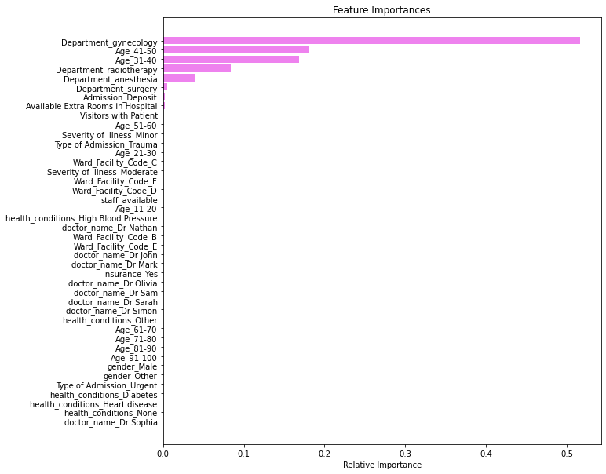

```python
#Plotting the feature importance
features = list(x.columns)
importances = dtree_tuned_regressor.feature_importances_
indices = np.argsort(importances)

plt.figure(figsize=(10,10))
plt.title('Feature Importances')
plt.barh(range(len(indices)), importances[indices], color='violet', align='center')
plt.yticks(range(len(indices)), [features[i] for i in indices])
plt.xlabel('Relative Importance')
plt.show()
```

**Observaciones:**

### **Bagging Regressor**

```python
#Bagging Regressor
bagging_estimator=BaggingRegressor(random_state=1)

#Fitting the model
bagging_estimator.fit(x_train,y_train)

# Model Performance on test data i.e prediction
bagging_estimator_perf_test = model_performance_regression(bagging_estimator, x_test, y_test)

bagging_estimator_perf_test
```

|  | RMSE | MAE | R-squared | Adj. R-squared | MAPE |
| --- | --- | --- | --- | --- | --- |
| 0 | 1.36894 | 0.905205 | 0.970242 | 0.970229 | 7.648842 |

### **Tuned Bagging Regressor**

```python
# Choose the type of regressor.
bagging_tuned = BaggingRegressor(random_state=1)

# Grid of parameters to choose from
parameters = {"n_estimators": [10,15,20],
              "max_samples" : [0.8,1],
              "max_features" : [0.8,1]
             }


# Type of scoring used to compare parameter combinations
scorer = make_scorer(r2_score)

# Run the grid search
grid_obj = GridSearchCV(bagging_tuned , parameters, scoring=scorer,cv=5)
grid_obj = grid_obj.fit(x_train,y_train)

# Set the bagging_tuned_regressor to the best combination of parameters
bagging_tuned_regressor = grid_obj.best_estimator_

bagging_tuned_regressor.fit(x_train, y_train)
```

```
BaggingRegressor(max_features=0.8, max_samples=0.8, n_estimators=15,
                 random_state=1)
```

```python
#Get the score of tuned Bagging tree regressor
bagging_tuned_regressor_perf_test = model_performance_regression(bagging_tuned_regressor, x_test, y_test)
bagging_tuned_regressor_perf_test
```

|  | RMSE | MAE | R-squared | Adj. R-squared | MAPE |
| --- | --- | --- | --- | --- | --- |
| 0 | 1.536988 | 1.032587 | 0.962487 | 0.962471 | 8.952246 |

**El regresor de embolsado no tiene ningún atributo para calcular la importancia de la función en Sklearn. Entonces, pasemos al siguiente modelo**

### **Regresor de bosque aleatorio**

```python
#Random Forest Regressor
regressor = RandomForestRegressor(n_estimators = 100, random_state = 1)

#Fitting the model
regressor.fit(x_train, y_train)

# Model Performance on test data i.e prediction
regressor_perf_test = model_performance_regression(regressor, x_test, y_test)

regressor_perf_test
```

|  | RMSE | MAE | R-squared | Adj. R-squared | MAPE |
| --- | --- | --- | --- | --- | --- |
| 0 | 1.303684 | 0.86505 | 0.973011 | 0.973 | 7.314995 |

### **Regresor de bosque aleatorio ajustado**

**NOTA:** Debido a la gran cantidad de observaciones en los datos, el código de la siguiente celda para GridSearchCV puede tardar entre 1 y 2 horas en ejecutarse, según la configuración de su sistema.

```python
rf_tuned = RandomForestRegressor(random_state=1)

# Grid of parameters to choose from
parameters = {"n_estimators": [110, 120],
    "max_depth": [5, 7],
    "max_features": [0.8, 1]
             }

# Type of scoring used to compare parameter combinations
scorer = make_scorer(r2_score)

# Run the grid search
grid_obj = GridSearchCV(rf_tuned, parameters, scoring=scorer,cv=5)
grid_obj = grid_obj.fit(x_train,y_train)

# Set the rf_tuned_regressor to the best combination of parameters
rf_tuned_regressor = grid_obj.best_estimator_

rf_tuned_regressor.fit(x_train, y_train)
```

```
RandomForestRegressor(max_depth=7, max_features=0.8, n_estimators=120,
                      random_state=1)
```

```python
# Model Performance on test data i.e prediction
rf_tuned_regressor_perf_test = model_performance_regression(rf_tuned_regressor, x_test, y_test)

rf_tuned_regressor_perf_test
```

|  | RMSE | MAE | R-squared | Adj. R-squared | MAPE |
| --- | --- | --- | --- | --- | --- |
| 0 | 1.722809 | 1.156349 | 0.952868 | 0.952848 | 9.640594 |

**Observaciones:**

- El rendimiento del modelo ajustado en realidad se reduce en comparación con el modelo con parámetros predeterminados.
- Esto podría deberse a que hemos probado una cantidad muy pequeña de hiperparámetros y una cantidad menor de valores debido a los límites computacionales. Sin duda, podemos intentar mejorar el rendimiento del modelo ajustándolo aún más.

**Visualización de la importancia de la función**

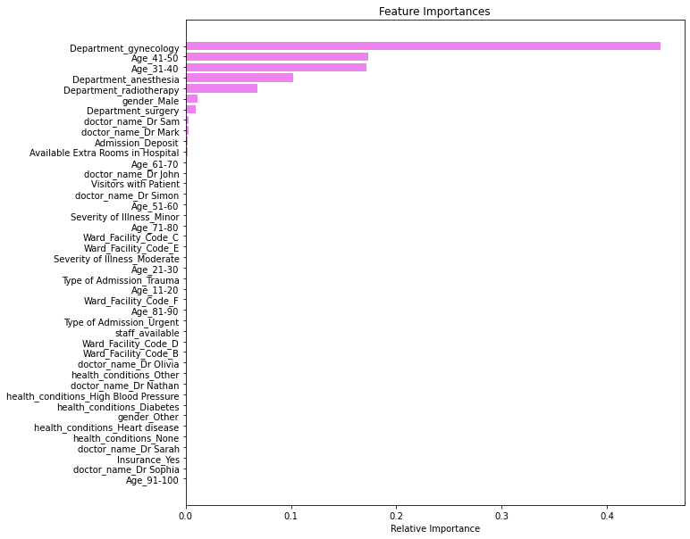

```python
#Plotting the feature importance
importances = rf_tuned_regressor.feature_importances_
indices = np.argsort(importances)

plt.figure(figsize=(10,10))
plt.title('Feature Importances')
plt.barh(range(len(indices)), importances[indices], color='violet', align='center')
plt.yticks(range(len(indices)), [features[i] for i in indices])
plt.xlabel('Relative Importance')
plt.show()
```

**Observaciones:**

- Las 3 principales variables importantes son las mismas que en el modelo de árbol de decisión. Hay algunas otras características como el género y los médicos que agregan algún valor al modelo.

**Comparación de rendimiento de modelos**

```python
models_test_comp_df = pd.concat(
    [
        lin_reg_test.T,
        ridge_regression_perf_test.T,
        dt_regressor_perf_test.T,
        regressor_perf_test.T,
        bagging_estimator_perf_test.T,
        dtree_tuned_regressor_perf_test.T,
        bagging_tuned_regressor_perf_test.T,
        rf_tuned_regressor_perf_test.T
    ],
    axis=1,
)

models_test_comp_df.columns = [
    "Linear Regression",
    "Ridge Regression",
    "Decision tree regressor",
    "Random Forest regressor",
    "Bagging regressor",
    "Tuned Decision Tree regressor",
    "Tuned Bagging Tree regressor",
    "Tuned Random Forest Regressor"]

print("Test performance comparison:")
models_test_comp_df
```

```
Test performance comparison:
```

|  | Linear Regression | Ridge Regression | Decision tree regressor | Random Forest regressor | Bagging regressor | Tuned Decision Tree regressor | Tuned Bagging Tree regressor | Tuned Random Forest Regressor |
| --- | --- | --- | --- | --- | --- | --- | --- | --- |
| RMSE | 3.144035 | 3.144039 | 1.815150 | 1.303684 | 1.368940 | 1.741743 | 1.536988 | 1.722809 |
| MAE | 2.155757 | 2.155819 | 1.128290 | 0.865050 | 0.905205 | 1.161072 | 1.032587 | 1.156349 |
| R-squared | 0.843030 | 0.843030 | 0.947680 | 0.973011 | 0.970242 | 0.951826 | 0.962487 | 0.952868 |
| Adj. R-squared | 0.842967 | 0.842964 | 0.947658 | 0.973000 | 0.970229 | 0.951806 | 0.962471 | 0.952848 |
| MAPE | 19.676878 | 19.677875 | 9.341248 | 7.314995 | 7.648842 | 9.646680 | 8.952246 | 9.640594 |

**Observaciones:**

- Todos los demás modelos ofrecen un buen rendimiento en términos de RMSE y R-cuadrado en comparación con la regresión lineal y de cresta.
- Los modelos de bagging y de random forest funcionan mejor que un solo árbol de decisión.
- El modelo de random forest con parámetros predeterminados está dando el mejor rendimiento entre todos los modelos entrenados.

### **Ajuste del modelo final elegido**

- Construcción del modelo final - Regresor de Random Forest
- Consideraremos Random Forest Regressor con parámetros predeterminados como nuestro modelo final.

```python
final_model = RandomForestRegressor(n_estimators = 100, random_state = 1)
final_model.fit(x_train, y_train)
```

```
RandomForestRegressor(random_state=1)
```

```python
final_model_perf_train = model_performance_regression(final_model, x_train, y_train)
```

```python
final_model_perf_train
```

|  | RMSE | MAE | R-squared | Adj. R-squared | MAPE |
| --- | --- | --- | --- | --- | --- |
| 0 | 0.487743 | 0.321099 | 0.996195 | 0.996195 | 2.71949 |

- **Tanto el R-cuadrado como el R-cuadrado ajustado del modelo son aproximadamente el 99,6 % de los datos de entrenamiento.** Esto indica que el modelo puede explicar aproximadamente la varianza completa en la variable objetivo usando las variables independientes.
- Hagamos una comprobación rápida del rendimiento de los datos de prueba.

```python
final_model_test_perf = model_performance_regression(final_model, x_test, y_test)
print("Test Performance:")
final_model_test_perf
```

```
Test Performance:
```

|  | RMSE | MAE | R-squared | Adj. R-squared | MAPE |
| --- | --- | --- | --- | --- | --- |
| 0 | 1.303684 | 0.86505 | 0.973011 | 0.973 | 7.314995 |

- El modelo también está dando un buen rendimiento en los datos de prueba, es decir, el modelo está dando un rendimiento generalizado.
- Las unidades de RMSE y MAE son las mismas, días en este caso. Pero RMSE es mayor que MAE porque penaliza más a los valores atípicos.
- **El MAE < 1 indica que el modelo es capaz de predecir la duración de la estancia con un error medio de 1 día,** lo cual es un muy buen desempeño.
- **MAPE de 7.31 en los datos de prueba indica que el modelo puede predecir dentro de ~7% de la duración real de la estadía de los pacientes.**

## **Contenido adicional (opcional)**

## **Impulsando modelos**

Veamos ahora el otro tipo de técnica de Ensemble - Impulsar Modelos

### **XGBoost**

- XGBoost significa Aumento de gradiente extremo.
- XGBoost es una técnica de aprendizaje automático de conjuntos basada en árboles que mejora el poder de predicción y el rendimiento al improvisar en el marco Gradient Boosting e incorporar algunos algoritmos de aproximación confiables. Se utiliza ampliamente y aparece habitualmente en la parte superior de las tablas de clasificación de la competencia en ciencia de datos.

```python
#installing the xgboost library using "pip' command.
!pip install xgboost
```

```python
#importing the Random Forest Regressor and Bagging Regressor [Bagging]
from sklearn.ensemble import RandomForestRegressor, BaggingRegressor

#importing the AdaBoostRegressor and GradientBoostingRegressor [Boosting]
from sklearn.ensemble import AdaBoostRegressor, GradientBoostingRegressor

#importing the XGBReressor from the xgboost
from xgboost import XGBRegressor
```

```python
#Adaboost Regressor
adaboost_model = AdaBoostRegressor(random_state=1)

#Fitting the model
adaboost_model.fit(x_train,y_train)

# model Performance on test data i.e prediction
adaboost_model_perf_test = model_performance_regression(adaboost_model, x_test, y_test)

adaboost_model_perf_test
```

|  | RMSE | MAE | R-squared | Adj. R-squared | MAPE |
| --- | --- | --- | --- | --- | --- |
| 0 | 2.375388 | 1.58689 | 0.910399 | 0.910362 | 13.623722 |

```python
#Gradient Boost Regressor
gbc = GradientBoostingRegressor(random_state=1)
gbc.fit(x_train,y_train)
gbc_perf_test = model_performance_regression(gbc, x_test, y_test)
```

```python
gbc_perf_test
```

|  | RMSE | MAE | R-squared | Adj. R-squared | MAPE |
| --- | --- | --- | --- | --- | --- |
| 0 | 1.792721 | 1.212749 | 0.948965 | 0.948944 | 10.247284 |

```python
#XGBoost Regressor
xgb = XGBRegressor(random_state=1, eval_metric='logloss')
xgb.fit(x_train,y_train)
xgb_perf_test = model_performance_regression(xgb, x_test, y_test)
```

```python
xgb_perf_test
```

|  | RMSE | MAE | R-squared | Adj. R-squared | MAPE |
| --- | --- | --- | --- | --- | --- |
| 0 | 1.510606 | 1.033003 | 0.963764 | 0.963748 | 8.867275 |

### **Ajuste de hiperparámetros: refuerzo**

El ajuste de hiperparámetros es una gran técnica en el aprendizaje automático para desarrollar el modelo con parámetros óptimos. Si el tamaño de los datos aumenta, el tiempo de cálculo aumentará durante el proceso de entrenamiento.

- A efectos prácticos, hemos enumerado a continuación algunos de los hiperparámetros importantes de cada algoritmo que se pueden ajustar para mejorar el rendimiento del modelo.

**1. Adaboost**

- Algunos hiperparámetros importantes que se pueden ajustar:
  - Objeto **base_estimator**, predeterminado=Ninguno El estimador base a partir del cual se construye el conjunto potenciado. Si es Ninguno, el estimador base es DecisionTreeRegressor inicializado con max_depth=3.
  - **n_estimadors**int, predeterminado=50 El número máximo de estimadores en los que finaliza el refuerzo. En el caso de un ajuste perfecto, el procedimiento de aprendizaje se detiene antes de tiempo. -**loss:**{'lineal', 'cuadrado', 'exponencial'}, predeterminado='lineal' La función de pérdida que se utilizará al actualizar los pesos después de cada iteración de impulso. -**learning_rate** flotante, predeterminado=1.0 Peso aplicado a cada regresor en cada iteración de impulso. Una mayor tasa de aprendizaje aumenta la contribución de cada regresor.

**2. Algoritmo de aumento de gradiente**

- Algunos hiperparámetros importantes que se pueden ajustar:
  - **n_estimadors**: el número de etapas de refuerzo que se realizarán. -**máx_depth**: limita el número de nodos en el árbol. El mejor valor depende de la interacción de las variables de entrada.
  - **min_samples_split**: el número mínimo de muestras requeridas para dividir un nodo interno.
  - **learning_rate**: cuánto se reducirá la contribución de cada árbol.

  -**loss**: función de pérdida a optimizar.

Para comprender mejor cada parámetro en Gradient Boosting Regressor, consulte esta [fuente](https://scikit-learn.org/stable/modules/generated/sklearn.ensemble.GradientBoostingRegressor.html#sklearn.ensemble.GradientBoostingRegressor) .**3. Algoritmo XGBoost**- - Algunos hiperparámetros importantes que se pueden ajustar: -**booster**[predeterminado= gbtree] Qué refuerzo usar. Puede ser gbtree, gblinear o dart; gbtree y dart usan modelos basados en árboles, mientras que gblinear usa funciones lineales. -**min_niño_peso** [predeterminado=1]

```
    La suma mínima de peso de instancia (hessian) necesaria en un hijo. Si el paso de partición del árbol da como resultado un nodo hoja con la suma del peso de la instancia menor que min_child_weight, entonces el proceso de construcción renunciará a seguir partiendo. En la tarea de regresión lineal, esto corresponde simplemente al número mínimo de instancias necesarias para estar en cada nodo. Cuanto mayor sea min_child_weight, más conservador será el algoritmo.
```

Para comprender mejor cada parámetro en XGBoost Regressor, consulte esta [fuente] (https://xgboost.readthedocs.io/en/stable/parameter.html).

### **Comparación de todos los modelos que hemos construido hasta ahora**

```python
models_test_comp_df = pd.concat(
    [
        lin_reg_test.T,
        ridge_regression_perf_test.T,
        dt_regressor_perf_test.T,
        regressor_perf_test.T,
        bagging_estimator_perf_test.T,
        adaboost_model_perf_test.T,
        gbc_perf_test.T,
        xgb_perf_test.T

    ],
    axis=1,
)

models_test_comp_df.columns = [
    "Linear Regression",
    "Ridge Regression",
    "Decision tree regressor",
    "Random Forest regressor",
    "Bagging regressor",
    "Adaboost regressor",
    "Gradientboost regressor",
    "XGBoost regressor"
]

print("Test performance comparison:")
```

```
Test performance comparison:
```

```python
models_test_comp_df
```

|  | Linear Regression | Ridge Regression | Decision tree regressor | Random Forest regressor | Bagging regressor | Adaboost regressor | Gradientboost regressor | XGBoost regressor |
| --- | --- | --- | --- | --- | --- | --- | --- | --- |
| RMSE | 3.144035 | 3.144039 | 1.815150 | 1.303684 | 1.368940 | 2.375388 | 1.792721 | 1.510606 |
| MAE | 2.155757 | 2.155819 | 1.128290 | 0.865050 | 0.905205 | 1.586890 | 1.212749 | 1.033003 |
| R-squared | 0.843030 | 0.843030 | 0.947680 | 0.973011 | 0.970242 | 0.910399 | 0.948965 | 0.963764 |
| Adj. R-squared | 0.842967 | 0.842964 | 0.947658 | 0.973000 | 0.970229 | 0.910362 | 0.948944 | 0.963748 |
| MAPE | 19.676878 | 19.677875 | 9.341248 | 7.314995 | 7.648842 | 13.623722 | 10.247284 | 8.867275 |

**Observaciones:**

- Con los parámetros predeterminados, los métodos de bagging superan a los métodos de refuerzo.
- **El Random Forest Regressor ofrece el mejor rendimiento para este conjunto de datos.**